# IE360 HW1

HW 1

Ceren Dündar

13 04 2022

# 1 Introduction

Time changes what current people want and need. There are many reasons such as the world economy, global problems, politics, technology level and the decrease in limited resources to affect people’s consumption habits. Buying a personal car is also consumer behavior. To see what affects this behavior more clearly, I chose 3 different data from different categories which are related to each other.

From EVDS, these data categories are used:

1. Surveys Category (Seasonally Unadjusted Consumer Confidence Index and Indices of Consumer Tendency Survey Questions, The probability of buying a car (over the next 12 months))
2. Exchange rates (Exchange rates,USD Buying)
3. Prices Indices (Europe Brent Spot Price FOB (TL per Barrel))

From Google Trends, “Araba Fiyatlari” keyword is used.

Firstly, 3 datasets are determined from 3 different data category in EVDS website. From exchange rates category, USD/TL rate is chosen because Turkey is a foreign-dependent country in some important industrial areas, and the change in the dollar rate affects the consumption of everyone, from people to large institutions. As we know lately, the sudden rise of the dollar directly affected the price of everything, and it is reflected in consumption habits. Since the automotive sector is an expensive sector with nearly 98% import ratio for Turkey, the increase in the dollar affects the automotive prices in the country in a short time. For this reason, the other dataset I chose is the probability of buying a car from surveys data category. Thirdly and lastly, I chose petrol barrel prices. Like many other countries in Europe, Turkey is a petrol importing country. When the dollar exchange rate increases, the money paid for petrol increases exponentially. Since petrol prices increase a lot, people start to turn to public transportation instead of buying a car. On the other hand, the increase in petrol prices is a factor that increases inflation in the country, and car purchases are expected to decrease as inflation increases, car prices will increase even more. Each of them is related to each other from different aspects.

To sum up, my research question is based on to understand whether the probability of buying a car has a relation with the petrol price and/or dollar exchange rate. Monthly based time series datasets and keyword “Araba Fiyatlari” data are tried to be compared, analyzed and visualized in the analysis section.

# 2 Data Loading

Here libraries are imported

```r
library(ggplot2)
library(dplyr)
library(tidyr)
library(readxl)
library(lubridate)
library(zoo)
library(corrplot)
library(hrbrthemes)
library(viridis)
library(ggridges)

setwd("C:/Users/Asus/Desktop/IE360/hw1")

data<-read_excel("data/dataa.xlsx")

data<-data%>%rename(Date=Tarih,
                      Gas.Prices=`TP BRENTPETROL EUBP`,
                      ExchangeRate_USD=`TP DK USD A YTL`,
                      Vehicle.purchase.prob=`TP TG2 Y17`,
                      Google.word.Arabafiyatlari=`Google`)%>%
  mutate(Date=as.Date(as.yearmon(Date)))

data<-data[,c(1,2,3,4,5)]
```

# 3 Analysis and Visualization of Time Series

## 3.1 Visualization

Monthly time series of 3 data and 1 keyword data for nine years are plotted as follows:

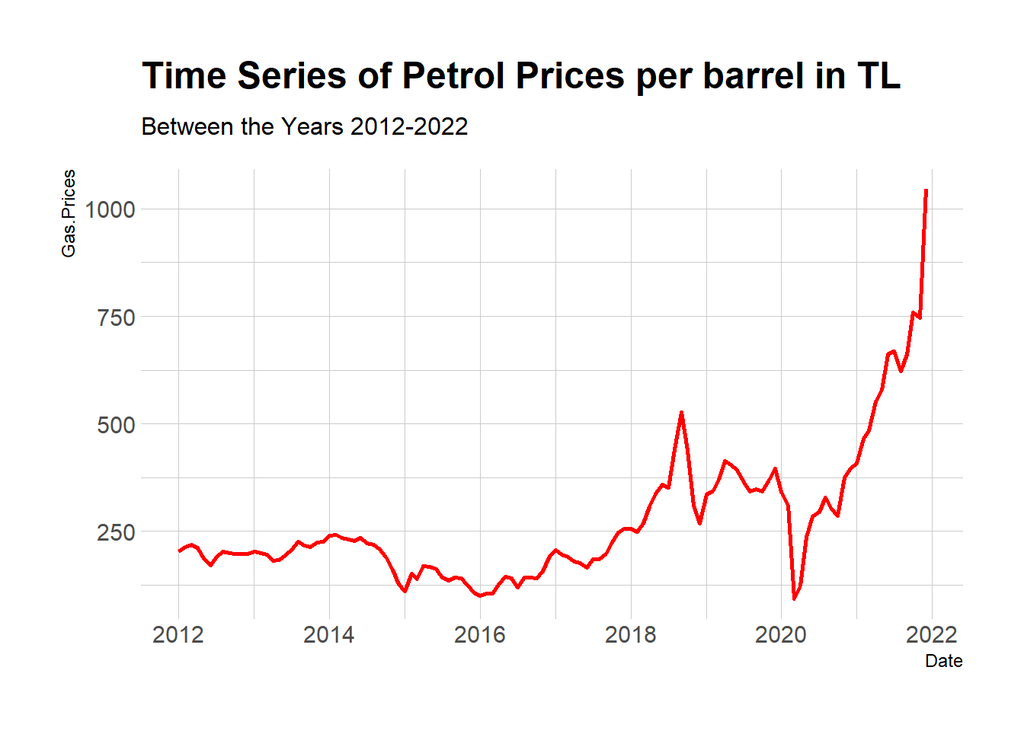

```r
ggplot(data,aes(x=Date))+
  geom_line(size=1,color="red",aes(y=Gas.Prices))+
  theme_ipsum()+
  ggtitle("Time Series of Petrol Prices per barrel in TL",
          subtitle="Between the Years 2012-2022")
```

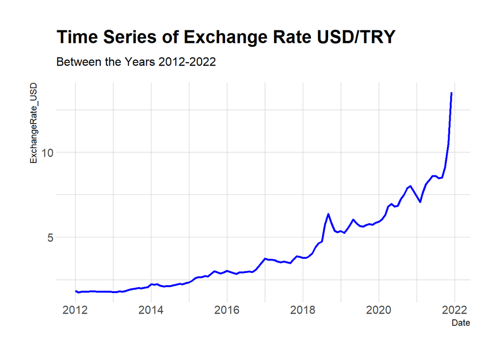

```r
ggplot(data,aes(x=Date))+
  geom_line(size=1,color="blue",aes(y=ExchangeRate_USD))+
  theme_ipsum()+
  ggtitle("Time Series of Exchange Rate USD/TRY",
          subtitle="Between the Years 2012-2022")
```

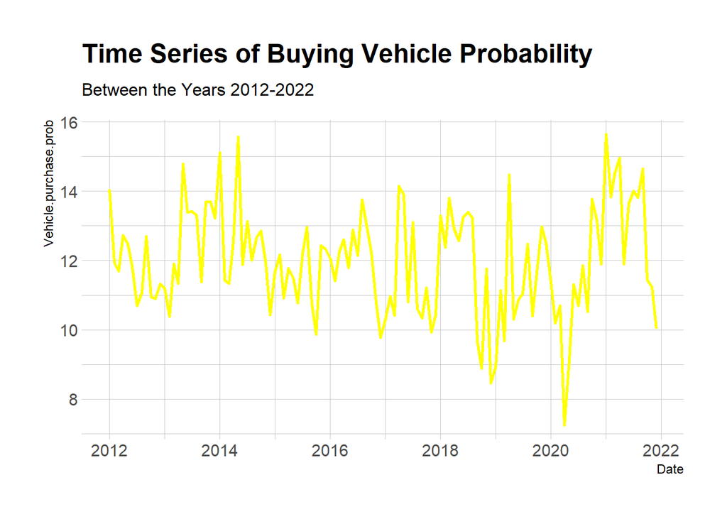

```r
ggplot(data,aes(x=Date))+
  geom_line(size=1,color="yellow",aes(y=Vehicle.purchase.prob))+
  theme_ipsum()+
  ggtitle("Time Series of Buying Vehicle Probability",
          subtitle="Between the Years 2012-2022")
```

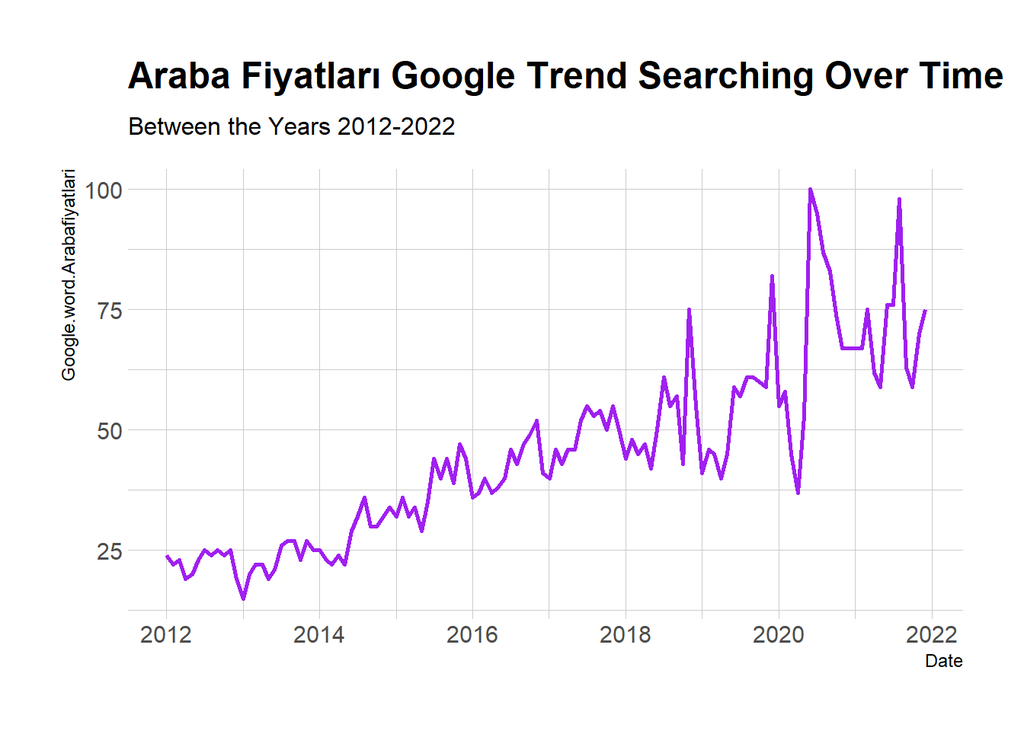

```r
ggplot(data,aes(x=Date))+
  geom_line(size=1,color="purple",aes(y=Google.word.Arabafiyatlari))+
  theme_ipsum()+
  ggtitle("Araba Fiyatları Google Trend Searching Over Time",
          subtitle="Between the Years 2012-2022")
```

## 3.2 Analysis

Analysis of Change in Petrol Price change in TL between 2012-2022:

- The sharp drop in petrol prices from mid-2014 to 2015 was primarily driven by supply factors, including booming U.S. oil production, receding geopolitical concerns, and shifting OPEC policies. We can see this decrease on the graph.
- We can see a sharp increase in October-November 2018. It can be the cause of the energy crisis in Turkey at the end of 2018. After the sharp increase, it fell down again in 2019. Because the suppliers oversupplied petrol when the price increased, it fell so sharp again in 2019.
- In March 2020, Coronavirus started and life stopped outside, people did not go to outside and there were quarantines, restrictions by government for transportation between cities. People started to work from home instead of going by their cars and many other reasons. All decreased petrol consumption, and less consumption caused less demand and price for petrol. Actually not even only for Turkey, Petrol prices due to less consumption were decreased all around the world.
- Since the end of 2020, Turkey has been struggling with economical issues. Because we import petrol, prices continue to increase due to the economic difficulties and inflation experienced throughout the country. In addition to the exchange rate effect, the value of oil in dollar terms is increasing, which creates a double effect. It will continue to increase due to Ukraine-Russia situation.

Analysis of Change in USD/TL Exchange Rate between 2012-2022:

- There is a high correlation between petrol prices in TL and USD/TL exchange rate. When we compare the graph of them, it is easy to see the similarity. The reason is petrol is sold with foreign currency and when the currency increases, prices in TL increase for many sources and products.

Analysis of Change in Probability of Buying Vehicle between 2012-2022:

- There is a small decreasing trend until the middle of 2020 but there is no pattern. The lowest value was observed in March-April-May 2020. Because the corona had just begun, people could not predict how long it would last and were not interested in buying a car.

## 3.3 Individual Analysis for “Araba Fiyatları” Google Trend Searching Over Time vs. Others

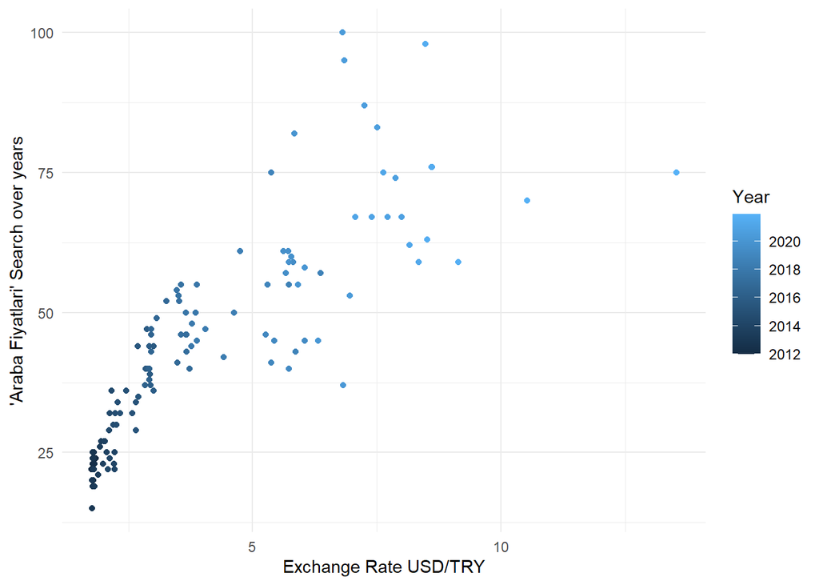

```r
ggplot(data)+
  geom_point(aes(x=ExchangeRate_USD,y=Google.word.Arabafiyatlari, color=as.Date(Date)))+
  theme_minimal()+
  labs(x="Exchange Rate USD/TRY", y="'Araba Fiyatlari' Search over years", color="Year")
```

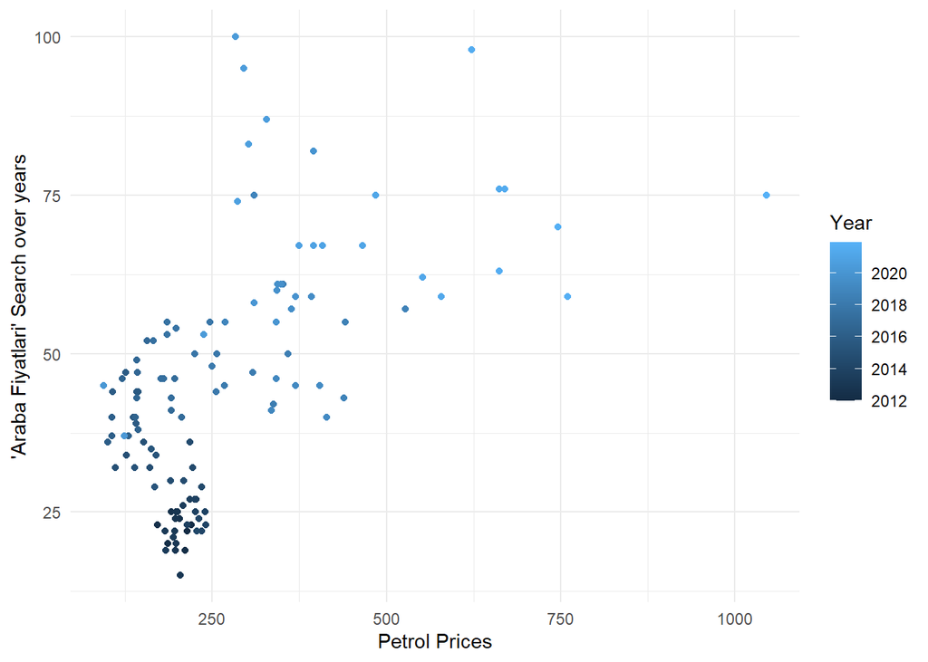

```r
ggplot(data)+
  geom_point(aes(x=Gas.Prices,y=Google.word.Arabafiyatlari, color=as.Date(Date)))+
  theme_minimal()+
  labs(x="Petrol Prices", y="'Araba Fiyatlari' Search over years", color="Year")
```

In the previous years, there is a correlation between USD/TRY rate and “araba fiyatlari” google trend search. But they do not seem relevant in the last years, so there is no correlation for last years. It is the same for petrol prices and “araba fiyatlari” google search plot.

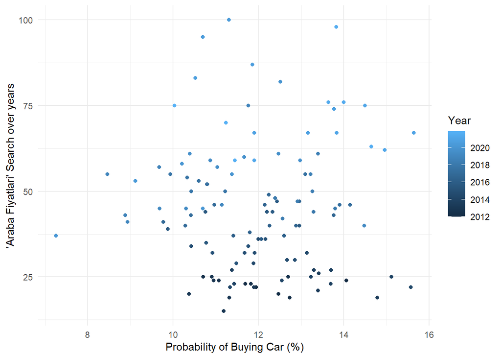

```r
ggplot(data)+
  geom_point(aes(x=Vehicle.purchase.prob,y=Google.word.Arabafiyatlari, color=as.Date(Date)))+
  theme_minimal()+
  labs(x="Probability of Buying Car (%)", y="'Araba Fiyatlari' Search over years", color="Year")
```

There is no clear correlation between probability of buying a car and “araba fiyatlari” google search.

## 3.4 Visualization of Pairwise Correlations

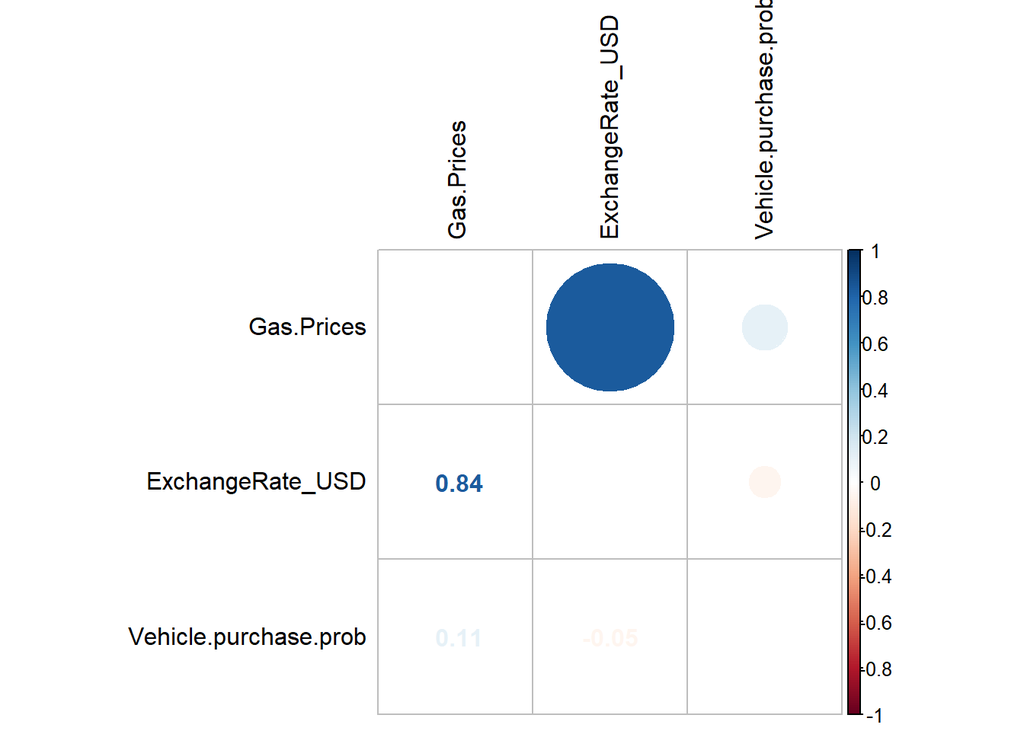

```r
cor_numVar <- cor(data[,c(2,3,4)], use="pairwise.complete.obs")

corrplot.mixed(cor_numVar, tl.col="black", tl.pos = "lt")
```

There is a high correlation between USD/TL currency rate and Petrol Price in Turkey with 0.84. As I explain in the Analysis and Visualization part, it is expected because Turkey is a dependent country for petrol, there is no production in Turkey for petrol. When the USD/TL rate increased, it increases gas prices,too. It is a positive correlation. There is so small correlation between gas prices and vehicle purchase probability and I did not expect it. But it is so small value, so we may not consider it. As I expected, there is a negative correlation even it is so small, between vehicle buying probability and USD/TL rate. As I told, when the currency rate increases, prices for automobiles increase. I expect from people to not want to buy a car with huge prices.

## 3.5 Correlation included Google Trend keyword

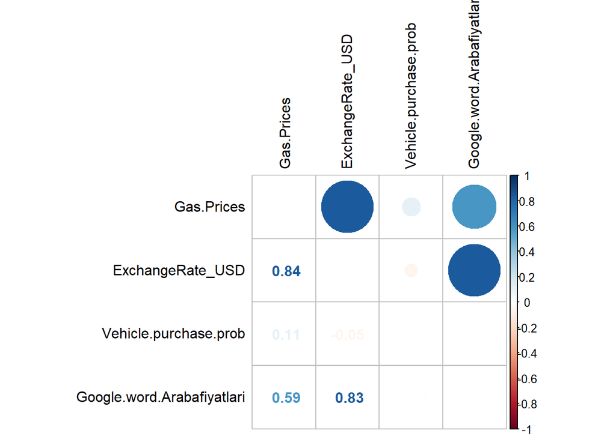

```r
cor_numVar <- cor(data[,c(2,3,4,5)], use="pairwise.complete.obs")

corrplot.mixed(cor_numVar, tl.col="black", tl.pos = "lt")
```

There is a high positive correlation between searching “Araba Fiyatlari” and USD/TL exchange rate. USD/TL rate affects automobile prices and market in Turkey, because Turkey is an import country in automotive industry. When the exchange rate incrases, prices for automobiles increase in Turkey. People search more about “Araba Fiyatlari” to fast changes in the market and prices. There is also similar relation between searching “Araba Fiyatlari” and Petrol Prices in TL in Turkey.

# 4 Conclusion

# 5 References

- https://blogs.worldbank.org/developmenttalk/what-triggered-oil-price-plunge-2014-2016-and-why-it-failed-deliver-economic-impetus-eight-charts#